# LendingClubData- LoanDefaultPrediction

```python
import numpy as np
import pandas as pd
import matplotlib.pyplot as plt
import seaborn as sns
import re
import warnings

from sklearn.preprocessing import OneHotEncoder
from sklearn.model_selection import GridSearchCV, train_test_split
from sklearn.ensemble import RandomForestClassifier
from sklearn.linear_model import LogisticRegression
from sklearn.metrics import roc_auc_score, roc_curve

warnings.filterwarnings('ignore')
pd.set_option('display.max_columns', None)
pd.set_option('display.max_rows', None)
```

```python
loan2011 = pd.read_csv('LendingClub/LoanStats2011.csv', header=1, chunksize=100000)
loan2013 = pd.read_csv('LendingClub/LoanStats2013.csv', header=1, chunksize=100000)
loan2014 = pd.read_csv('LendingClub/LoanStats2014.csv', header=1, chunksize=100000)
loan2015 = pd.read_csv('LendingClub/LoanStats2015.csv', header=1, chunksize=100000)

Q1_2016 = pd.read_csv('LendingClub/LoanStats_2016Q1.csv', header=1, chunksize=100000)
Q2_2016 = pd.read_csv('LendingClub/LoanStats_2016Q2.csv', header=1, chunksize=100000)
Q3_2016 = pd.read_csv('LendingClub/LoanStats_2016Q3.csv', header=1, chunksize = 100000)
Q4_2016 = pd.read_csv('LendingClub/LoanStats_2016Q4.csv', header=1, chunksize = 100000)

Q1_2017 = pd.read_csv('LendingClub/LoanStats_2017Q1.csv', header=1, chunksize = 100000)
Q2_2017 = pd.read_csv('LendingClub/LoanStats_2017Q2.csv', header=1, chunksize = 100000)
Q3_2017 = pd.read_csv('LendingClub/LoanStats_2017Q3.csv', header=1, chunksize = 100000)
Q4_2017 = pd.read_csv('LendingClub/LoanStats_2017Q4.csv', header=1, chunksize = 100000)

Q1_2018 = pd.read_csv('LendingClub/LoanStats_2018Q1.csv', header=1, chunksize = 100000)
Q2_2018 = pd.read_csv('LendingClub/LoanStats_2018Q2.csv', header=1, chunksize = 100000)
Q3_2018 = pd.read_csv('LendingClub/LoanStats_2018Q3.csv', header=1, chunksize = 100000)
Q4_2018 = pd.read_csv('LendingClub/LoanStats_2018Q4.csv', header=1, chunksize = 100000)

Q1_2019 = pd.read_csv('LendingClub/LoanStats_2019Q1.csv', header=1, chunksize = 100000)
```

```python
chunk_list = []
files = [loan2011, loan2013, loan2014, loan2015,
         Q1_2016, Q2_2016, Q3_2016, Q3_2016,
         Q1_2017, Q2_2017, Q3_2017, Q3_2017,
         Q1_2018, Q2_2018, Q3_2018, Q4_2018, Q1_2019]

for file in files:
    for chunk in file:
        chunk_list.append(chunk)

df_concat = pd.concat(chunk_list)
```

```python
column_names = ['loan_amnt', 'funded_amnt', 'term', 'int_rate', 'installment', 'grade',
               'emp_length', 'annual_inc', 'issue_d', 'loan_status', 'addr_state', 'dti',
               'delinq_2yrs', 'open_acc', 'pub_rec', 'total_acc', 'total_pymnt',
                'tot_cur_bal', 'total_bal_il', 'revol_bal']

data = df_concat.iloc[:, 2:][column_names]
```

```python
data.head(5)
```

[output not shown]

```python
data.isnull().sum()
```

[output not shown]

```python
data = data.dropna(subset=['loan_amnt', 'funded_amnt', 'dti',
                          'annual_inc', 'emp_length'])
```

```python
data['issue_y'] = data['issue_d'].apply(lambda x: str(x)[-4:])
```

# Loan Volume

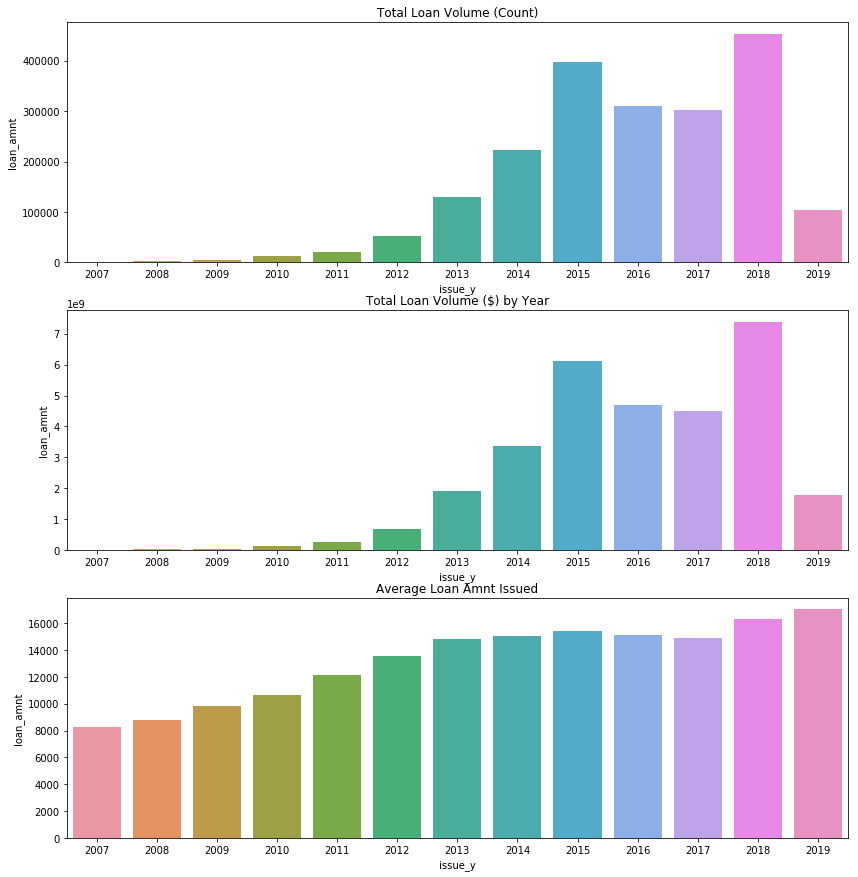

```python
fig, ax = plt.subplots(3, 1, figsize = (14, 15))

g = data.groupby(['issue_y'])['loan_amnt'].count().reset_index()
sns.barplot('issue_y', 'loan_amnt', data=g, ax=ax[0])
ax[0].set_title('Total Loan Volume (Count)')

g = data.groupby(['issue_y'])['loan_amnt'].sum().reset_index()
sns.barplot('issue_y', 'loan_amnt', data=g, ax= ax[1])
ax[1].set_title('Total Loan Volume ($) by Year')

g = data.groupby(['issue_y'])['loan_amnt'].mean().reset_index()
sns.barplot('issue_y', 'loan_amnt', data=g, ax=ax[2])
ax[2].set_title('Average Loan Amnt Issued')
```

2018 has the highest loan volume in terms of count and $.

The avarege loan amount has an increasing trend overall.

```
Stats for funded amount:
count    2.012615e+06
mean     1.536087e+04
std      9.242651e+03
min      5.000000e+02
25%      8.000000e+03
50%      1.350000e+04
75%      2.000000e+04
max      4.000000e+04
Name: funded_amnt, dtype: float64
```

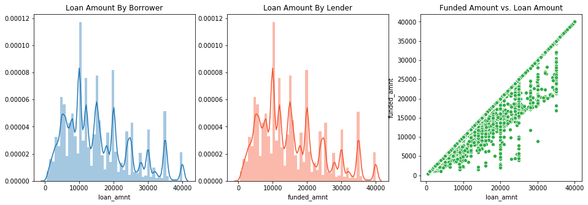

```python
f, ax = plt.subplots(1, 3, figsize = (16, 5))
sns.distplot(data['loan_amnt'], ax= ax[0])
ax[0].set_title('Loan Amount By Borrower')
sns.distplot(data['funded_amnt'], ax=ax[1], color="#F7522F")
ax[1].set_title('Loan Amount By Lender')
sns.scatterplot(x = 'loan_amnt', y = 'funded_amnt', data = data, ax = ax[2], color="#2EAD46")
ax[2].set_title('Funded Amount vs. Loan Amount')

print('Stats for funded amount:\n{}'.format( data['funded_amnt'].describe()))
```

The amount asked for by borrower and issued by lender have similar distribution. It means that once the loan is approved, the borrowers are likely to get the full amount they had applied for.

The median loan applied is around 13,000 USD. Most loans issued range from 10,000 to 20,000 USD.

```
Top 4 Loan Amountaddr_state
CA    4.393444e+09
TX    2.683873e+09
NY    2.515649e+09
FL    2.078645e+09
Name: loan_amnt, dtype: float64
```

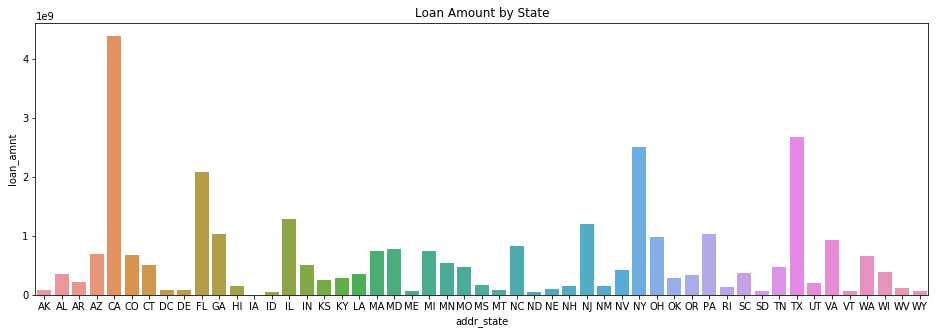

```python
print('Top 4 Loan Amount{}'.format(data.groupby('addr_state')['loan_amnt'].sum().nlargest(4)))
fig, ax = plt.subplots(1, 1, figsize = (16,5))

g = data.groupby('addr_state')['loan_amnt'].sum().reset_index()
sns.barplot(x = 'addr_state', y = 'loan_amnt', data = g, ax = ax)
ax.set_title('Loan Amount by State')
```

# Loan quality

```python
data['loan_status'].value_counts()
```

```
Fully Paid                                             1030776
Current                                                 709099
Charged Off                                             243244
Late (31-120 days)                                       16267
In Grace Period                                           7560
Late (16-30 days)                                         2940
Does not meet the credit policy. Status:Fully Paid        1965
Does not meet the credit policy. Status:Charged Off        746
Default                                                     18
Name: loan_status, dtype: int64
```

```python
bad_status = ['Charged Off', 'Late (31-120 days)', 'Late (16-30 days)'
       'Does not meet the credit policy. Status:Charged Off', 'Default']

data['loan_standing'] = np.nan

def loan_standing(status):
    if status in bad_status:
        return 'bad'
    else:
        return 'good'

data['loan_standing'] = data['loan_status'].apply(loan_standing)
```

```python
data['loan_target'] = np.where(data['loan_standing'] == 'good', 0, 1)
```

```python
data['int_rate'] = data['int_rate'].apply(lambda x: float(x.rstrip("%")))
```

```
[Text(0, 0.5, '% of Total Loans')]
```

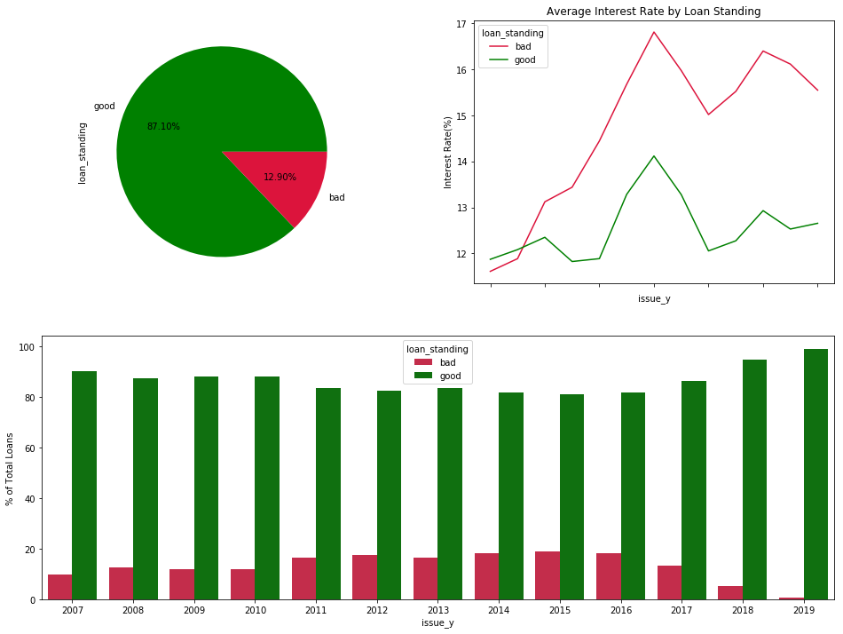

```python
f = plt.figure( figsize=(16,12))

ax0 = f.add_subplot(221)
ax1 = f.add_subplot(222)
ax2 = f.add_subplot(212)

colors = ['crimson', 'g']
labels ="Good Loans", "Bad Loans"

data['loan_standing'].value_counts().plot.pie(autopct='%1.2f%%', ax=ax0, colors = ['g', 'crimson'] )

data.groupby(['issue_y', 'loan_standing'])['int_rate'].mean().unstack().plot(ax = ax1, colors = colors)
ax1.set_title('Average Interest Rate by Loan Standing')
ax1.set_ylabel('Interest Rate(%)')

g = data.groupby(['issue_y', 'loan_standing'])['funded_amnt'].sum()
g = g.groupby(level = 0).apply(lambda x: x/x.sum() * 100).reset_index()
sns.barplot(x = 'issue_y', y = 'funded_amnt', hue = 'loan_standing', data=g, palette = colors)
ax2.set(ylabel='% of Total Loans')
```

Bad loans account for 13% of the loans.

Not surprisingly, bad loans have much higher interest rate than good loans. The median interest rate for bad loans and good laons are ~15% and ~12% respectively.

Loans issued in 2015 and 2016 have the highest portions ( ~18%) of bad loans. We should keep in mind that current loans have risking of becoming bad loans. ( For example, loans issued in 2019 do not have time to default yet since they were issued recently.)

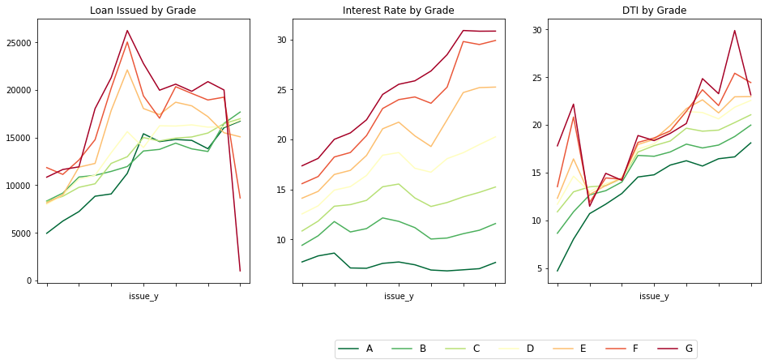

```python
f, ax = plt.subplots(1, 3, figsize = (16, 6))
cmap = 'RdYlGn_r'

data.groupby(['issue_y', 'grade'])['loan_amnt'].mean().unstack().plot(ax = ax[0], colormap = cmap, legend = False)
ax[0].set_title('Loan Issued by Grade')

data.groupby(['issue_y', 'grade'])['int_rate'].mean().unstack().plot(ax = ax[1], colormap = cmap, legend = False)
ax[1].set_title('Interest Rate by Grade')

data.groupby(['issue_y', 'grade'])['dti'].mean().unstack().plot(ax = ax[2], colormap = cmap)
ax[2].set_title('DTI by Grade')

ax[2].legend( bbox_to_anchor=(-1.0, -0.3, 1.7, 0.1), loc=5, prop={'size':12},
           ncol=7, mode="expand", borderaxespad=0.)
```

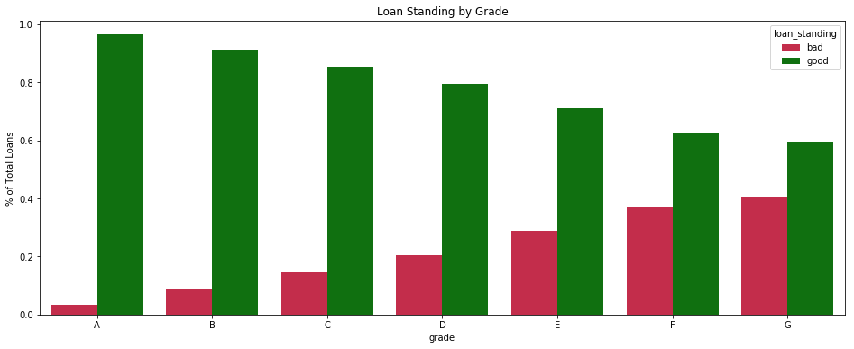

```python
f, ax = plt.subplots(1, 1, figsize = (16, 6))

g = data.groupby(['grade', 'loan_standing'])['loan_amnt'].count()
g = g.groupby(level = 0).apply(lambda x: x/x.sum()).reset_index()

sns.barplot(x = 'grade', y = 'loan_amnt', hue = 'loan_standing', data=g, palette = colors)
ax.set_title('Loan Standing by Grade')
ax.set_ylabel('% of Total Loans')
```

Not surprisingly, the lower the loan grade, the higher the interest rate. Lending Club needs to charge the lender higher interest rate to mitigate the risk.

Loans with bad ratings have a higher chance of default, late payments and charge offs.

```python
data['emp_length'].value_counts()
```

```
10+ years    708401
2 years      193147
< 1 year     184370
3 years      171964
1 year       142056
5 years      133590
4 years      129886
6 years       97390
7 years       88921
8 years       88362
9 years       74532
Name: emp_length, dtype: int64
```

```python
data = data.dropna(subset = ['annual_inc', 'emp_length'])
```

```python
data['emp_len'] = data['emp_length'].str.extract('(\d+)').astype(int)
```

```python
def income_bracket(income):
    if income <= 100000:
        return 'low'
    elif (income > 100000) & (income < 200000):
        return 'medium'
    elif income >= 200000:
        return 'high'

data['inc_bracket'] = data['annual_inc'].apply(income_bracket)
```

```python
data['inc_bracket'] = data['inc_bracket'].astype('category')
```

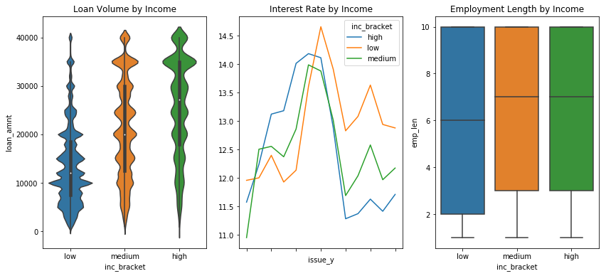

```python
fig, ax = plt.subplots(1, 3, figsize = (14, 6))

sns.violinplot(x='inc_bracket', y='loan_amnt', data=data, order = ['low', 'medium', 'high'], ax=ax[0])
ax[0].set_title('Loan Volume by Income')

data.groupby(['issue_y', 'inc_bracket'])['int_rate'].mean().unstack().plot(ax = ax[1])
ax[1].set_title('Interest Rate by Income')

sns.boxplot(x='inc_bracket', y="emp_len", data=data, order = ['low', 'medium', 'high'], ax=ax[2])
ax[2].set_title('Employment Length by Income')
```

Compared to low and medium income borrowers, high income borrowers take higher loan amounts.

```python
data['term'].value_counts()
```

```
 36 months    1415071
 60 months     597544
Name: term, dtype: int64
```

```python
data['term_int'] = data['term'].str.extract('(\d+)').astype(int)
```

```python
data['term_36'] = np.where(data['term_int'] == 36, 1, 0)
```

```python
data['grade'] = data['grade'].astype('category')
grade = np.array(data['grade']).reshape(-1, 1)
enc = OneHotEncoder(sparse = False)
grade_binary = enc.fit_transform(grade)
```

```python
grade_encode = grade_binary[:, :-1]
```

```python
grade_df = pd.DataFrame( grade_encode, columns = ['A', 'B', 'C', 'D', 'E', 'F'], dtype = int)
```

```python
columns = ['term_36', 'int_rate', 'emp_len', 'dti',
          'funded_amnt', 'total_pymnt', 'loan_target']

new_data = pd.concat([data[columns].reset_index(drop=True), grade_df.reset_index(drop=True)], axis = 1)
```

```python
new_data.head(5)
```

|  | term_36 | int_rate | emp_len | dti | funded_amnt | total_pymnt | loan_target | A | B | C | D | E | F |
| --- | --- | --- | --- | --- | --- | --- | --- | --- | --- | --- | --- | --- | --- |
| 0 | 1 | 10.65 | 10 | 27.65 | 5000.0 | 5863.155187 | 0 | 0 | 1 | 0 | 0 | 0 | 0 |
| 1 | 0 | 15.27 | 1 | 1.00 | 2500.0 | 1014.530000 | 1 | 0 | 0 | 1 | 0 | 0 | 0 |
| 2 | 1 | 15.96 | 10 | 8.72 | 2400.0 | 3005.666844 | 0 | 0 | 0 | 1 | 0 | 0 | 0 |
| 3 | 1 | 13.49 | 10 | 20.00 | 10000.0 | 12231.890000 | 0 | 0 | 0 | 1 | 0 | 0 | 0 |
| 4 | 0 | 12.69 | 1 | 17.94 | 3000.0 | 4066.908161 | 0 | 0 | 1 | 0 | 0 | 0 | 0 |

```python
#dti, grade, inc_bracket, terms, interest rate
X = new_data.loc[:, new_data.columns != 'loan_target']
y = new_data['loan_target']
```

```python
X.head(5)
```

|  | term_36 | int_rate | emp_len | dti | funded_amnt | total_pymnt | A | B | C | D | E | F |
| --- | --- | --- | --- | --- | --- | --- | --- | --- | --- | --- | --- | --- |
| 0 | 1 | 10.65 | 10 | 27.65 | 5000.0 | 5863.155187 | 0 | 1 | 0 | 0 | 0 | 0 |
| 1 | 0 | 15.27 | 1 | 1.00 | 2500.0 | 1014.530000 | 0 | 0 | 1 | 0 | 0 | 0 |
| 2 | 1 | 15.96 | 10 | 8.72 | 2400.0 | 3005.666844 | 0 | 0 | 1 | 0 | 0 | 0 |
| 3 | 1 | 13.49 | 10 | 20.00 | 10000.0 | 12231.890000 | 0 | 0 | 1 | 0 | 0 | 0 |
| 4 | 0 | 12.69 | 1 | 17.94 | 3000.0 | 4066.908161 | 0 | 1 | 0 | 0 | 0 | 0 |

```python
X_train, X_test, y_train, y_test = train_test_split(X, y, test_size=0.2, random_state=0)
```

```python
#logistic regression
clf = LogisticRegression(random_state=1)
clf.fit(X_train, y_train)
print('Accuracy:{}'.format( clf.score(X_test, y_test)))

y_scores = clf.predict_proba(X_test)[:,1]
print('AUC:{}'.format( roc_auc_score(y_test, y_scores)))
```

```
Accuracy:0.8696273256435036
AUC:0.6482021994562321
```

Logistic regression acheives ~86% accuracy and ~64% roc-auc score. Using acccuracy is inappropriate since we have quite an imbalanced class here. Logistic regression is easy to understand and can give good reason why certain loans are classified as bad. ROC-AUC score is however low so we want to explore other techniques.

```python
rf = RandomForestClassifier(random_state=1)
rf.fit(X_train, y_train)

y_scores = rf.predict_proba(X_test)[:,1]
print('AUC:{}'.format( roc_auc_score(y_test, y_scores)))
```

```
AUC:0.9286320673150786
```

Random Forest acheives ~92.8% roc-auc score. Random forest performs much better than logistic regression but we lost transparent as users do not know how it works.

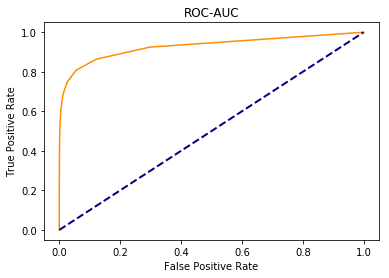

```python
fpr, tpr, thresholds = roc_curve(y_test, y_scores)
plt.plot(fpr, tpr, color = 'darkorange')
plt.plot([0, 1], [0, 1], color='navy', lw=2, linestyle='--')
plt.title('ROC-AUC')
plt.xlabel('False Positive Rate')
plt.ylabel('True Positive Rate')
```

Final remarks:

The final model has a auc of 92.8% which is pretty good. However,there are lots of work we can do to improve the model. We could use calculation or imputation for other fields to fill in null values. We could also explore more variables, such as, recent inquiries, loan purpose, to be included in the model. In additional, we can tune some of the hyper-parameters to avoid overfitting.